# Task 2: Agglomerative Hierarchical Clustering

Nick McManus

2023-02-27

```r
knitr::opts_chunk$set(echo = TRUE, message = FALSE, warning = FALSE)

library(tidyverse)   ## always
library(dendextend)  ## tanglegram to compare complete/single linkage
library(ggdendro)    ## plotting dendrogram nicely
```

# Introduction

This data comes from the Santa Barbara Coastal LTER, which collected water measurements from 2000 - 2018. The 13 sites are located in Santa Barbara area watersheds, stretching roughly from Gaviota State Park to downtown Santa Barbara.

**Source:** Citation: Santa Barbara Coastal LTER and J. Melack. 2019. SBC LTER: Land: Stream chemistry in the Santa Barbara Coastal drainage area, ongoing since 2000 ver 16. Environmental Data Initiative. https://doi.org/10.6073/pasta/67a558a24ceed9a0a5bf5e46ab841174.

# Data wrangling

First, we read in the raw data and wrangle it to later perform an hierarchical clustering by complete linkages. First, any variables with high (>50%) occurrence of NAs are removed. The remaining data then undergoes a listwise deletion to return only observations with data for every variable. The average stream chemistry values are calculated by site, and then the data is scaled to more easily calculate euclidean distances.

```r
### read in data
stream_chem <- read_csv('sbc_lter_registered_stream_chemistry.csv') %>%
  ## convert -999 values to NA
  na_if(-999) %>%
  ## add stream names
  mutate(site_name = case_when(site_code == 'AB00' ~ 'Arroyo Burro',
                               site_code == 'AT07' ~ 'Atascadero Creek',
                               site_code == 'BC02' ~ 'Bell Canyon Creek',
                               site_code == 'DV01' ~ 'Devereaux Creek',
                               site_code == 'GV01' ~ 'Gaviota',
                               site_code == 'HO00' ~ 'Arroyo Hondo',
                               site_code == 'MC00' ~ 'Mission Creek (Montecito St)',
                               site_code == 'MC06' ~ 'Mission Creek (Rocky Nook)',
                               site_code == 'ON02' ~ 'San Onofre Creek',
                               site_code == 'RG01' ~ 'Refugio Creek',
                               site_code == 'RS02' ~ 'Rattlesnake Creek',
                               site_code == 'SP02' ~ 'San Pedro Creek',
                               site_code == 'TO02' ~ 'Tecolote Creek'),
         .after = site_code)


### explore the number of NAs by variable
# colSums(is.na(stream_chem))
   # site_code   timestamp_local            nh4_uM            no3_uM
   #         0                 0               203               149
   #    po4_uM            tdn_uM            tdp_uM            tpc_uM
   #       167              5034              5801             16521
   #    tpn_uM            tpp_uM    tss_mgperLiter spec_cond_uSpercm
   #     16521             17046             14376               924


### tpc, tpn, tpp, and tss all have more than 50% NAs.
### Let's drop them from the analysis,
### then find the average values by stream site.
stream_chem_avgs <- stream_chem %>%
  select(!c(tpc_uM, tpn_uM, tpp_uM, tss_mgperLiter)) %>%
  drop_na() %>%
  group_by(site_name) %>%
  summarize(nh4_mean = mean(nh4_uM, na.rm = TRUE),
            no3_mean = mean(no3_uM, na.rm = TRUE),
            po4_mean = mean(po4_uM, na.rm = TRUE),
            tdn_mean = mean(tdn_uM, na.rm = TRUE),
            tdp_mean = mean(tdp_uM, na.rm = TRUE),
            spec_cond_mean = mean(spec_cond_uSpercm, na.rm = TRUE))


### scale the numeric data
stream_chem_scale <- stream_chem_avgs %>%
  select(where(is.numeric)) %>%
  scale()

### reassign rownames based on site name
rownames(stream_chem_scale) <- stream_chem_avgs$site_name
```

# Hierarchical clustering

For a bottom-up hierarchical cluster, we first need to calculate the Euclidean distance in multivariate space between the different observations. Then, we use this matrix of distances (dissimilarity matrix) to perform a complete hierarchical clustering. The results are visualized by the dendrogram in Figure 1 below.

```r
### calculate euc dists
euc_dist <- dist(stream_chem_scale, method = 'euclidean')

### use stats::hclust() for hierarchical clustering
stream_hc_complete <- hclust(euc_dist, method = 'complete')

### quick base plot check:
# plot(stream_hc_complete, cex = 0.6, hang = -1)
```

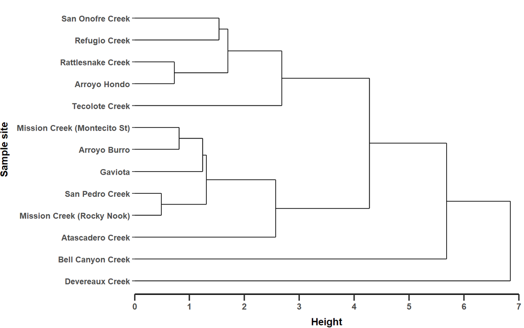

```r
### Dendrogram plot
ggdendrogram(stream_hc_complete,
             rotate = TRUE,
             labels = TRUE) +
  theme_classic() +
  labs(x = "Sample site",
       y = "Height") +
  scale_y_continuous(breaks = seq(0, 7, by = 1),
                     expand = c(0, 0), limits = c(0, 7)) +
  theme(
    ## x axis
    axis.line.x = element_line(linewidth = 0.8),
    axis.ticks.x = element_line(linewidth = 0.8),
    axis.ticks.length.x = unit(.25, 'cm'),
    axis.text.x = element_text(face = 'bold', size = 9.5),
    axis.title.x = element_text(face = 'bold', size = 11, vjust = -1),
    ## y axis
    axis.line.y = element_blank(),
    axis.title.y = element_text(face = 'bold', size = 11, vjust = 3.5),
    axis.text.y = element_text(face = 'bold', size = 9))
```

**Figure 1.** Santa Barbara Coastal LTER stream chemistry hierarchical clustering by complete linkage. The x-axis of this dendrogram indicates how closely related the stream chemistry is by water sample sites, on average.

# Complete vs. Single Linkage

Here we compare how hierarchical clustering results differ when using complete vs. single linkages.

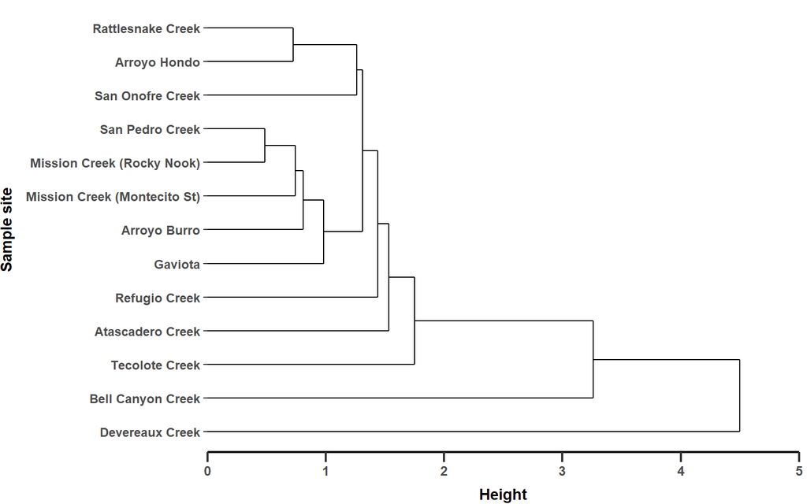

```r
### Single-linkage
stream_hc_single <- hclust(euc_dist, method= 'single')

### Quick base plot check:
# plot(hc_single, cex = 0.9, hang = -1)

### Dendrogram plot
ggdendrogram(stream_hc_single,
             rotate = TRUE,
             labels = TRUE) +
  theme_classic() +
  labs(x = "Sample site",
       y = "Height") +
  scale_y_continuous(breaks = seq(0, 5, by = 1),
                     expand = c(0, 0), limits = c(0, 5)) +
  theme(
    ## x axis
    axis.line.x = element_line(linewidth = 0.8),
    axis.ticks.x = element_line(linewidth = 0.8),
    axis.ticks.length.x = unit(.25, 'cm'),
    axis.text.x = element_text(face = 'bold', size = 9.5),
    axis.title.x = element_text(face = 'bold', size = 11, vjust = -1),
    ## y axis
    axis.line.y = element_blank(),
    axis.title.y = element_text(face = 'bold', size = 11, vjust = 3.5),
    axis.text.y = element_text(face = 'bold', size = 9))
```

**Figure 2.** Santa Barbara Coastal LTER stream chemistry hierarchical clustering by single linkage.

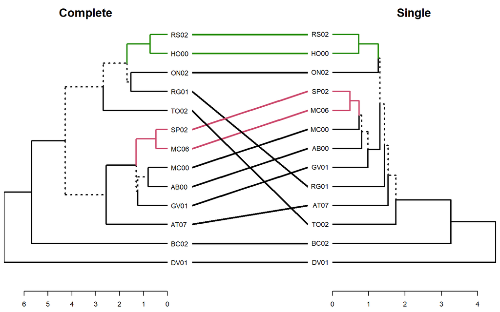

```r
### Let's make a tanglegram to directly compare!

### First let's convert names to codes
### so that they're visible in figure ------------------------------------------
stream_chem_avgs_code <- stream_chem %>%
  select(!c(tpc_uM, tpn_uM, tpp_uM, tss_mgperLiter)) %>%
  drop_na() %>%
  group_by(site_code) %>%
  summarize(nh4_mean = mean(nh4_uM, na.rm = TRUE),
            no3_mean = mean(no3_uM, na.rm = TRUE),
            po4_mean = mean(po4_uM, na.rm = TRUE),
            tdn_mean = mean(tdn_uM, na.rm = TRUE),
            tdp_mean = mean(tdp_uM, na.rm = TRUE),
            spec_cond_mean = mean(spec_cond_uSpercm, na.rm = TRUE))
## scale the numeric data
stream_chem_scale_code <- stream_chem_avgs_code %>%
  select(where(is.numeric)) %>%
  scale()
## reassign rownames based on site name
rownames(stream_chem_scale_code) <- stream_chem_avgs_code$site_code
## calculate euc dists
euc_dist_code <- dist(stream_chem_scale_code, method = 'euclidean')
## find complete and single linkages
stream_hc_complete_code <- hclust(euc_dist_code, method = 'complete')
stream_hc_single_code <- hclust(euc_dist_code, method = 'single')


### Convert both HC's to dendrogram class --------------------------------------
dend_complete <- as.dendrogram(stream_hc_complete_code)
dend_single <- as.dendrogram(stream_hc_single_code)

### Make a tanglegram
# tanglegram(dend_complete, dend_single)

### How similar are they?
# entanglement(dend_complete, dend_single)
# [1] 0.2774816

### Can we get the number lower (better) by untangling a bit?
# untangle(dend_complete, dend_single, method = 'step1side') %>%
#   entanglement()
# [1] 0.1690201

### Plot the untangled tanglegram!
tangle <- untangle(dend_complete, dend_single, method = 'step1side') %>%
  tanglegram(common_subtrees_color_branches = TRUE,
             main_left = "Complete",
             main_right = "Single",
             cex_main = 1.7,
             lwd = 2.5, edge.lwd = 2)
```

**Figure 3.** Tanglegram comparing the complete (left) vs single (right) linkage methods for hierarchical clustering of Santa Barbara Coastal LTER stream chemistry sites.

- On average, the stream chemistry at Bell Canyon Creek (BC02) and Devereaux Creek (DV01) are the most dissimilar from the other 11 sample sites when clustering by either complete or single linkage.
- Figure 3 directly compares the single and complete linkage methods for agglomerative hierarchical clustering. Using single linkage, all sites are related more quickly (height < 5) than with complete linkage (height < 7).
- Refugio Creek (RG01) and Tecolote Creek (TO02) move the most when comparing the linkage methods.
- Complete linkage results in more apparent clusters between stream sites.